# Multinomial Probability Distribution

Now we don’t just have success or not success, we got a bunch of options.

Let Y be the categorical response random variable with level j = 1,….J where each category has probability $\large \pi_j = P(Y = j)$ such that $\large \sum^J_{j=1}\pi_j = 1$. If there are $n$ identical trials with responses $\large Y_1,…,Y_n$ , then we can define random variables $\large N_j, j = 1,…,J$ such that $\large N_j$ counts the number of trials responding with category j.

So $\large N_j = \sum^n_{i = 1}(Y_i = j)$. Also with $\large n$ being a response… then for category j $\large \sum^j_{j = 1} n_j = n$.

#### Multinomial PDF

$$\large P(N_1 = n_1,...,N_j = n_j) =
\frac{n!}{\Pi^J_{j=1}n_j!}\Pi^J_{j=1}\pi^{n_j}_j$$

Where j is a category. So with this, you figure out the probability of the j response. If J=2, then there’s only two responses and thus it’s a binomial distribution.

#### MLE of Multinomial $\large \pi$

$$\large \hat{\pi} = \frac{n_j}{n}$$

### Multinomial Simulation Example:

$$\large \pi_1 =0.25, \pi_2 = 0.35, \pi_3 = 0.2, \pi_4 =0.1, \pi_5 = 0.1$$

```r
pi.j <- c(0.25, 0.35, 0.2, 0.1, 0.1) #all the pi's for each j
set.seed(2195)
n.j <- rmultinom(n =1, size = 1000, prob = pi.j) #n = 1 means one set of size = 1000 trials. this would return all the n's for each j
data.frame(n.j, pihat.j = n.j/1000, pi.j)
```

```
##   n.j pihat.j pi.j
## 1 242   0.242 0.25
## 2 333   0.333 0.35
## 3 188   0.188 0.20
## 4 122   0.122 0.10
## 5 115   0.115 0.10
```

```r
pi.j <- c(0.25, 0.35, 0.2, 0.1, 0.1) #all the pi's for each j
set.seed(9182)
n.j <- rmultinom(n =5, size = 1000, prob = pi.j) #n = 5 means five set of size = 1000 trials. this would return all the n's for each j from each trial
n.j
```

```
##      [,1] [,2] [,3] [,4] [,5]
## [1,]  259  259  237  264  247
## [2,]  341  346  374  339  341
## [3,]  200  188  198  191  210
## [4,]   92  106   89  108  107
## [5,]  108  101  102   98   95
```

This get’s complicated:

#### One multinomial distribution

Think of there being a big contingency table. The left vertical X will be values for an X variable. The horizontal upper Y will be responses and their values. Let’s say X is a variable with values child, teen, and adult while Y is a variable with values elementary, middle, and high. You know what nvm.

PMF for N_11,…NIJ

$$\large P(N_{11} = n_{11},...N_{IJ} = n_{IJ}) =
\frac{n!}{\Pi^I_{i=1}\Pi^J_{j=1}n_{ij}!}\Pi^I_{i =
1}\Pi^J_{j=1}\pi^{n_{ij}}_{ij}$$

Which is also the likelihood function for a sample of size n^

You can take the marginal distributions for X and Y as well through some math.

#### I multinomial distributions

$$\large P(N_{i1} = n_{i1},...N_{iJ} = n_{iJ}|N_{i+} = n_{i+}) =
\frac{n!}{\Pi^I_{i=1}n_{ij}!}\Pi^J_{j=1}\pi^{n_{ij}}_{ij}$$

For a given i, or for a given X value, then you ca find the probability of it having a certain Y value, or a certain j value.

Likelihood for parameters:

$$\large \Pi_{i = 1}^I \frac{n_{i+}!}{\Pi^J_{j =
1}n_{ij}!}\Pi^J_{j=1}\pi^{n_{ij}}_{j|i}$$

As a result, this model is often referred to as the product multinomial model. The MLE of $\large \pi_{j|i}$ is $\large \hat{\pi}_{j|i} = n_{ij}/n_{i+}$. Or the same thing as $\large P(Y = j|X=i) = (X = i, Y=j)/ P(X-i)$ .

##### One multinomial simulated sample

```r
#Probabilities entered by column for array()
pi.ij <- c(0.2, 0.3, 0.2, 0.1, 0.1, 0.1)
pi.table <- array(data = pi.ij, dim = c(2,3), dimnames = list(X = 1:2, Y = 1:3))
pi.table #pi_ij
```

```
##    Y
## X     1   2   3
##   1 0.2 0.2 0.1
##   2 0.3 0.1 0.1
```

```r
set.seed(9812)
save <- rmultinom(n = 1, size = 1000, prob = pi.ij)
c.table1 <- array(data = save, dim = c(2,3), dimnames = list(X = 1:2, y = 1:3))
c.table1
```

```
##    y
## X     1   2   3
##   1 191 206  94
##   2 311  95 103
```

```r
c.table1/sum(c.table1)
```

```
##    y
## X       1     2     3
##   1 0.191 0.206 0.094
##   2 0.311 0.095 0.103
```

##### I multinomial simulated sample

```r
pi.cond <- pi.table/rowSums(pi.table) #basically making each X value sum up to 1 in probability
pi.cond #pi_j|i
```

```
##    Y
## X     1   2   3
##   1 0.4 0.4 0.2
##   2 0.6 0.2 0.2
```

```r
set.seed(8111)
save1 <- rmultinom(n = 1, size = 400, prob = pi.cond[1,])
save2 <- rmultinom(n = 1, size = 600, prob = pi.cond[2,])

c.table2 <- array(data = c(save1[1], save2[1], save1[2], save2[2], save1[3], save2[3]), dim = c(2,3), dimnames = list(X = 1:2, Y = 1:3))
c.table2
```

```
##    Y
## X     1   2   3
##   1 162 159  79
##   2 351 126 123
```

```r
rowSums(c.table2)
```

```
##   1   2
## 400 600
```

```r
c.table2/rowSums(c.table2) #Estimated of pi_j|i
```

```
##    Y
## X       1      2      3
##   1 0.405 0.3975 0.1975
##   2 0.585 0.2100 0.2050
```

```r
round(c.table1/rowSums(c.table1),4) # From 1 multinomial
```

```
##    y
## X       1      2      3
##   1 0.389 0.4196 0.1914
##   2 0.611 0.1866 0.2024
```

### Test for independence

$$\large \begin{align}
&H_0 \;: \; \pi_{ij} = \pi_{i +}\pi_{+j} \;for\;each\;i,j\\
&H_a \; : \; \pi_{ij}\neq \pi_{i +} \pi_{+j} \; for \; some\; i,j
\end{align}$$

Performed by using a Pearson chi-square test and a LRT.

Test statistic is:

$$\large X^2 = \sum^I_{i = 1}\sum^J_{j=1}\frac{(n_{ij} -
n_{i+}n_{ij}/n)^2}{n_{i+}n_{ij}/n}$$

Reject null hypothesis of independence between X and Y when:

$$\large X > \chi^2_{(I-1)(J-1), 1-\alpha}$$

The likelihood ratio is the same.

$$\large -2log(\Lambda) = 2\sum^I_{i = 1}\sum^J_{j =
1}n_{ij}log\left(\frac{n_{ij}}{n_{i+}n_{ij}/n}\right)$$

```r
diet <- read.csv(file = "./Fiber.csv")
head(diet)
```

```
##   fiber  bloat count
## 1  bran   high     0
## 2   gum   high     5
## 3  both   high     2
## 4  none   high     0
## 5  bran medium     1
## 6   gum medium     3
```

```r
diet$fiber <- factor(x = diet$fiber, levels = c("none", "bran", "gum", "both"))
diet$bloat <- factor(x = diet$bloat, levels = c("none", "low", "medium", "high"))
diet.table <- xtabs(formula = count ~ fiber + bloat, data = diet)
diet.table
```

```
##       bloat
## fiber  none low medium high
##   none    6   4      2    0
##   bran    7   4      1    0
##   gum     2   2      3    5
##   both    2   5      3    2
```

We can test if bloating severity is related to the type of fiber by test of independence. There are three ways to do this:

```r
ind.test <- chisq.test(x = diet.table, correct = FALSE)
ind.test
```

```
##
##  Pearson's Chi-squared test
##
## data:  diet.table
## X-squared = 16.943, df = 9, p-value = 0.04962
```

```r
library(package = vcd)
assocstats(x = diet.table)
```

```
##                     X^2 df P(> X^2)
## Likelihood Ratio 18.880  9 0.026230
## Pearson          16.943  9 0.049621
##
## Phi-Coefficient   : NA
## Contingency Coeff.: 0.511
## Cramer's V        : 0.343
```

```r
class(diet.table)
```

```
## [1] "xtabs" "table"
```

```r
summary(diet.table)
```

```
## Call: xtabs(formula = count ~ fiber + bloat, data = diet)
## Number of cases in table: 48
## Number of factors: 2
## Test for independence of all factors:
##  Chisq = 16.943, df = 9, p-value = 0.04962
##  Chi-squared approximation may be incorrect
```

```r
qchisq(p = 0.95, df = 9)
```

```
## [1] 16.91898
```

We get the warning that chi-squared approx. may be incorrect because $\large n_{i+}n_{+j}/n >5$ is not true.

```r
#Expected cell counts under independence
ind.test$expected
```

```
##       bloat
## fiber  none  low medium high
##   none 4.25 3.75   2.25 1.75
##   bran 4.25 3.75   2.25 1.75
##   gum  4.25 3.75   2.25 1.75
##   both 4.25 3.75   2.25 1.75
```

Unfortunately, odds ratios and and examining the residuals are not that great of looking at association between X and Y. Still, they can be helpful.

```r
#Residuals of observed cell count vs expected under deviance under a stand normal. If += 2, then its unnusual. We look if things increase or nota s well. If large and the opposite sign in one row, then points to a violation of independence
ind.test$stdres
```

```
##       bloat
## fiber        none        low     medium       high
##   none  1.2196992  0.1797866 -0.2135042 -1.6527877
##   bran  1.9166701  0.1797866 -1.0675210 -1.6527877
##   gum  -1.5681846 -1.2585064  0.6405126  3.0694629
##   both -1.5681846  0.8989331  0.6405126  0.2361125
```

## Nominal response regression models

Where we model the probabilities of the response variable Y with response categories j = 1,…, J using explanatory variables x1,…xp

Baseline category logits is when you compare j = 1 to any other j = 2,…J.

$$\large log(\pi_j/\pi_1) = \beta_{j0} + \beta_{j1}x$$

We can also compare to other baselines:

$$\large log(\pi_2/\pi_3) = \beta_{20} - \beta_{30} + x(\beta_{21} -
\beta_{31})$$

We find a particular pi for a j with:

$$\large \pi_j = \frac{exp(\beta_{j0} + \beta_{j1}x_1 + ...+
\beta_{jp}x_p)}{1+\sum^J_{j=2}exp(\beta_{j0} +
\beta_{j1}x_1+...+\beta_{jp}x_p)}$$

```r
wheat <- read.csv(file = "./wheat.csv")

head(wheat, n = 3)
```

```
##   class  density hardness    size  weight moisture    type
## 1   hrw 1.349253 60.32952 2.30274 24.6480 12.01538 Healthy
## 2   hrw 1.287440 56.08972 2.72573 33.2985 12.17396 Healthy
## 3   hrw 1.233985 43.98743 2.51246 31.7580 11.87949 Healthy
```

```r
tail(wheat, n = 3)
```

```
##     class   density hardness    size  weight moisture type
## 273   srw 0.8491887 34.06615 1.40665 12.0870 11.92744 Scab
## 274   srw 1.1770230 60.97838 1.05690  9.4800 12.24046 Scab
## 275   srw 1.0305543 -9.57063 2.05691 23.8185 12.64962 Scab
```

```r
 # Parallel coordinate plot

    library(package = MASS)  # Location of parcoord() function

    # Reorder variables because class is binary (may distort plot)
    # Create indicator variable for class
    wheat2<-data.frame(kernel = 1:nrow(wheat), wheat[,2:6],
           class.new = ifelse(test = wheat$class == "hrw", yes = 0, no = 1))
    head(wheat2)
```

```
##   kernel  density hardness    size  weight moisture class.new
## 1      1 1.349253 60.32952 2.30274 24.6480 12.01538         0
## 2      2 1.287440 56.08972 2.72573 33.2985 12.17396         0
## 3      3 1.233985 43.98743 2.51246 31.7580 11.87949         0
## 4      4 1.336534 53.81704 2.27164 32.7060 12.11407         0
## 5      5 1.259040 44.39327 2.35478 26.0700 12.06487         0
## 6      6 1.300258 48.12066 2.49132 33.2985 12.18577         0
```

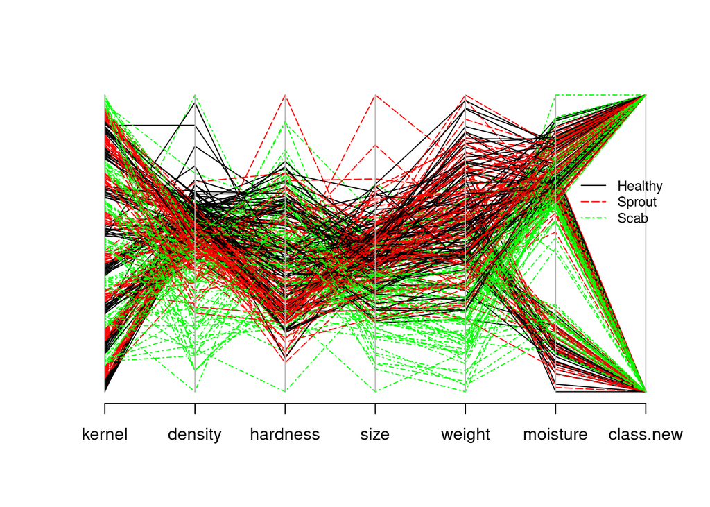

```r
    # Colors by condition:
    wheat.colors<-ifelse(test = wheat$type=="Healthy", yes = "black",
                    no = ifelse(test = wheat$type=="Sprout", yes = "red", no = "green"))
    # Line type by condition:
    wheat.lty<-ifelse(test = wheat$type=="Healthy", yes = "solid",
                    no = ifelse(test = wheat$type=="Sprout", yes = "longdash", no = "dotdash"))

    parcoord(x = wheat2, col = wheat.colors, lty = wheat.lty)  # Plot
    legend(x = 6.15, y = 0.75, legend = c("Healthy", "Sprout", "Scab"), lty = c("solid", "longdash", "dotdash"),
      col=c("black", "red", "green"), cex=0.8, bty="n")
```

```r
levels(wheat$type) # The 3 response categories
```

[output not shown]

```r
library(package = nnet)
mod.fit <- multinom(formula = type ~ class + density + hardness + size + weight + moisture , data = wheat)
summary(mod.fit) # healthy isnt on there since it is base level
```

```
## Call:
## multinom(formula = type ~ class + density + hardness + size +
##     weight + moisture, data = wheat)
##
## Coefficients:
##        (Intercept)   classsrw   density    hardness      size     weight
## Scab      30.54650 -0.6481277 -21.59715 -0.01590741 1.0691139 -0.2896482
## Sprout    19.16857 -0.2247384 -15.11667 -0.02102047 0.8756135 -0.0473169
##           moisture
## Scab    0.10956505
## Sprout -0.04299695
##
## Std. Errors:
##        (Intercept)  classsrw  density    hardness      size     weight
## Scab      4.289865 0.6630948 3.116174 0.010274587 0.7722862 0.06170252
## Sprout    3.767214 0.5009199 2.764306 0.008105748 0.5409317 0.03697493
##         moisture
## Scab   0.1548407
## Sprout 0.1127188
##
## Residual Deviance: 384.2247
## AIC: 412.2247
```

So this means:

$$\large \begin{align}
&log(\hat{\pi}_{Scab}/ \hat{\pi}_{Healthy}) = 30.55 - 0.65srw -
21.60 density- 0.016 hardness + 1.07size - 0.29 weight + 0.11 moisture
\\
&log(\hat{\pi}_{Sprout}/ \hat{\pi}_{Healthy}) = 19.17- 0.22srw-
15.12 density- 0.021 hardness + 0.88size - 0.047 weight -0.043 moisture
\end{align}$$

```r
library(package = car)
Anova(mod.fit)
```

```
## Analysis of Deviance Table (Type II tests)
##
## Response: type
##          LR Chisq Df Pr(>Chisq)
## class       0.964  2     0.6175
## density    90.555  2  < 2.2e-16 ***
## hardness    7.074  2     0.0291 *
## size        3.211  2     0.2008
## weight     28.230  2  7.411e-07 ***
## moisture    1.193  2     0.5506
## ---
## Signif. codes:  0 '***' 0.001 '**' 0.01 '*' 0.05 '.' 0.1 ' ' 1
```

```r
pi.hat <- predict(object = mod.fit, newdata = wheat, type = 'probs')
head(pi.hat)
```

```
##     Healthy        Scab     Sprout
## 1 0.8552110 0.046396827 0.09839221
## 2 0.7492553 0.021572158 0.22917255
## 3 0.5172800 0.068979903 0.41374011
## 4 0.8982064 0.006740716 0.09505287
## 5 0.5103245 0.176260796 0.31341473
## 6 0.7924907 0.015304122 0.19220522
```

Wald CI for probabilities

```r
#Obtain observation values
x1 <- 0
x2 <- wheat[1,2]
x3 <- wheat [1,3]
x4 <- wheat[1,4]
x5 <- wheat[1,5]
x6 <- wheat[1,6]

g.healthy <- "1/(1+exp(b20 + b21*x1 + b22 * x2 + b23*x3 + b24*x4 + b25*x5 + b26*x6) + exp(b30 + b31*x1 + b32*x2 + b33*x3 + b34*x4 + b35*x5 + b36*x6))"

calc.healthy <- deltaMethod(object = mod.fit, g = g.healthy, parameterNames = c("b20", "b21", "b22", "b23", "b24", "b25", "b26", "b30", "b31", "b32", "b33", "b34", "b35", "b36"))

calc.healthy$Estimate #pi-hat_Healthy
```

```
## [1] 0.855211
```

```r
calc.healthy$SE #sqrt(Var-hat(pi-hat_Healthy))
```

```
## [1] 0.05999678
```

```r
alpha <- 0.05
calc.healthy$Estimate + qnorm(p = c(alpha/2, 1-alpha/2)) * calc.healthy$SE
```

```
## [1] 0.7376194 0.9728025
```

### Odds ratios

Consider the model:

$$\large log(\pi_j/\pi_1) = \beta_{j0} + \beta_{j1}$$

for j = 2,… J

The odds of a category j response vs a category 1 response is $\large exp(\beta_{j0} + \beta_{j1}x)$. Thus, the odds of a category j vs. a category 1 response change by $\large e^{c\beta_{j1}}$ times for every c-unit increase in x.

Similarily, for any odds ratio besides the base level:

$$\large e^{c(\beta_{j1} - \beta_{j'1})}$$

```r
sd.wheat <- apply (X = wheat[, -c(1,7,8)], MARGIN = 2, FUN = sd) #1 sd to choose c
c.value <- c(1, sd.wheat) #class = 1 is first value
round(c.value, 2) #values of c for the base level 1(healthy)
```

```
##           density hardness     size   weight moisture
##     1.00     0.13    27.36     0.49     7.92     2.03
```

```r
#beta.hat_jr for r =1, ..., 6 and j = 2,3, where beta.hat_jr = coefficients(mod.fit[j-1,r+1])
beta.hat2 <- coefficients(mod.fit)[1, 2:7]
beta.hat3 <- coefficients(mod.fit)[2,2:7]

#Odds ratios for j = 2 vs j =1 (scab vs healthy)
round(exp(c.value*beta.hat2), 2)
```

```
##           density hardness     size   weight moisture
##     0.52     0.06     0.65     1.69     0.10     1.25
```

```r
round(1/exp(c.value*beta.hat2), 2)
```

```
##           density hardness     size   weight moisture
##     1.91    17.04     1.55     0.59     9.90     0.80
```

```r
#Odds ratios for j = 3 vs. j = 1 (sprout vs healthy)
round(exp(c.value*beta.hat3), 2)
```

```
##           density hardness     size   weight moisture
##     0.80     0.14     0.56     1.54     0.69     0.92
```

```r
round(1/exp(c.value*beta.hat3), 2)
```

```
##           density hardness     size   weight moisture
##     1.25     7.28     1.78     0.65     1.45     1.09
```

```r
class(mod.fit)
```

```
## [1] "multinom" "nnet"
```

```r
methods(class = multinom)
```

```
##  [1] add1        anova       Anova       brief       coef        confint
##  [7] Confint     deltaMethod drop1       extractAIC  logLik      model.frame
## [13] predict     print       S           summary     vcov
## see '?methods' for accessing help and source code
```

```r
sqrt(vcov(mod.fit)[2,2]) #sqrt(Var-hat(beta-hat_21))
```

```
## [1] 0.6630948
```

Wald CI of Odds Ratios

```r
conf.beta <- confint(object = mod.fit, level = 0.95)
round(conf.beta,2) # Results are in a 3D array
```

```
## , , Scab
##
##              2.5 % 97.5 %
## (Intercept)  22.14  38.95
## classsrw     -1.95   0.65
## density     -27.70 -15.49
## hardness     -0.04   0.00
## size         -0.44   2.58
## weight       -0.41  -0.17
## moisture     -0.19   0.41
##
## , , Sprout
##
##              2.5 % 97.5 %
## (Intercept)  11.78  26.55
## classsrw     -1.21   0.76
## density     -20.53  -9.70
## hardness     -0.04  -0.01
## size         -0.18   1.94
## weight       -0.12   0.03
## moisture     -0.26   0.18
```

```r
ci.OR2 <- exp(c.value*conf.beta[2:7, 1:2, 1])
ci.OR3 <- exp(c.value*conf.beta[2:7, 1:2 ,2])

round(data.frame(low = ci.OR2[,1], up = ci.OR2[,2]), 2)
```

```
##           low   up
## classsrw 0.14 1.92
## density  0.03 0.13
## hardness 0.37 1.12
## size     0.80 3.55
## weight   0.04 0.26
## moisture 0.67 2.32
```

```r
round(data.frame(low = 1/ci.OR2[,2], up = 1/ci.OR2[,1]), 2)[c(2,5),]
```

```
##          low    up
## density 7.64 38.00
## weight  3.80 25.79
```

```r
round(data.frame(low = ci.OR3[,1], up = ci.OR3[,2]), 2)
```

```
##           low   up
## classsrw 0.30 2.13
## density  0.07 0.28
## hardness 0.36 0.87
## size     0.91 2.59
## weight   0.39 1.22
## moisture 0.58 1.44
```

```r
round(data.frame(low = 1/ci.OR3[,2], up = 1/ci.OR3[,1]), 2)[c(2,5),]
```

```
##          low    up
## density 3.57 14.82
## weight  0.82  2.58
```

With 95% confidence, the odds of a scab instead of a healthy kernel change by 7.64 to 38.00 times when density is decreased by 0.13 holding the other variables constant. Also, with 95% confidence, the odds of a sprout instead of a healthy kernel change by 3.57 and 14.82 times when desnity is decreased by 0.13 holding the other variables constant.

#### Contingency tables

```r
library(package = nnet)
mod.fit.nom <- multinom(formula = bloat ~ fiber, weights = count, data = diet) #use weights = count because each row of diet represents contingency table counts, not observaitons from individual trials
summary(mod.fit.nom)
```

```
## Call:
## multinom(formula = bloat ~ fiber, data = diet, weights = count)
##
## Coefficients:
##        (Intercept)  fiberbran   fibergum fiberboth
## low     -0.4057626 -0.1538545  0.4055575  1.322135
## medium  -1.0980713 -0.8481379  1.5032639  1.503764
## high   -12.4401085 -4.1103893 13.3561038 12.440403
##
## Std. Errors:
##        (Intercept)    fiberbran   fibergum  fiberboth
## low      0.6455526    0.8997698   1.190217   1.056797
## medium   0.8163281    1.3451836   1.224593   1.224649
## high   205.2385583 1497.8087307 205.240263 205.240994
##
## Residual Deviance: 108.3915
## AIC: 132.3915
```

$$\large log(\pi_j/\pi_{none}) = \beta_{j0} + \beta_{j1}bran +
\beta_{j2}gum + \beta_{j3}both$$

```r
#test of independence
library(package = car)
Anova(mod.fit.nom)
```

```
## Analysis of Deviance Table (Type II tests)
##
## Response: bloat
##       LR Chisq Df Pr(>Chisq)
## fiber    18.88  9    0.02623 *
## ---
## Signif. codes:  0 '***' 0.001 '**' 0.01 '*' 0.05 '.' 0.1 ' ' 1
```

This proves that there is some dependence between type of fiber and severity of bloating.

Estimated log_odds comparing low bloating severity category to no bloating:

$$\large log(\hat{\pi}_{low}/ \hat{\pi}_{none}) = -0.41 - 0.15bran + 0.41
gum + 1.32both$$

This means that using gum, with or without bran, leads to a larger odds of low bloating relative to no bloating than does using no fiber. Contrast to this, there is a small effect in the oppostie direction of using bran or no fiber.

Computation of the estimated odds ratios:

```r
round(exp(coefficients(mod.fit.nom)[,-1]),2)
```

```
##        fiberbran fibergum fiberboth
## low         0.86      1.5      3.75
## medium      0.43      4.5      4.50
## high        0.02 631658.3 252812.49
```

For example, the estimated odds of having low bloating rather than none is exp(-0.15) = 0.86 times as large for using bran as a fiber source than using no fiber at all.

```r
diet$count2 <- ifelse(test = diet$count == 0, yes = diet$count +0.5, no = diet$count)
mod.fit.nom2 <- multinom(formula = bloat ~ fiber, weights = count2, data= diet)
sum.fit <- summary(mod.fit.nom2)
round(sum.fit$coefficients, 4)
```

```
##        (Intercept) fiberbran fibergum fiberboth
## low        -0.4055   -0.1541   0.4055    1.3218
## medium     -1.0986   -0.8473   1.5041    1.5040
## high       -2.4849   -0.1542   3.4012    2.4849
```

```r
round(sum.fit$standard.errors, 4)
```

```
##        (Intercept) fiberbran fibergum fiberboth
## low         0.6455    0.8997   1.1902    1.0567
## medium      0.8165    1.3452   1.2247    1.2247
## high        1.4719    2.0759   1.6931    1.7795
```

Much better. All the other estimated parameters are similar as well. Estimated odds ratios is now:

```r
round(exp(coefficients(mod.fit.nom2)[,-1]), 2)
```

```
##        fiberbran fibergum fiberboth
## low         0.86      1.5      3.75
## medium      0.43      4.5      4.50
## high        0.86     30.0     12.00
```

```r
conf.beta <- confint(object = mod.fit.nom2, level = 0.95)
round(exp(conf.beta[2:4,,3]),2) #compare high to no bloating
```

```
##           2.5 % 97.5 %
## fiberbran  0.01  50.13
## fibergum   1.09 828.46
## fiberboth  0.37 392.52
```

```r
#need to use factor to indicate it is a factor variable and not a char variable
diet$bran <- factor(ifelse(test = diet$fiber == "bran" | diet$fiber == "both", yes = "yes", no = "no"))
diet$gum <- factor(ifelse(test = diet$fiber == "gum" | diet$fiber == "both", yes = "yes", no = "no"))

head(diet, n = 4)
```

```
##   fiber bloat count count2 bran gum
## 1  bran  high     0    0.5  yes  no
## 2   gum  high     5    5.0   no yes
## 3  both  high     2    2.0  yes yes
## 4  none  high     0    0.5   no  no
```

```r
mod.fit.nom.inter <- multinom(formula = bloat ~ bran + gum + bran:gum, weights = count, data = diet)
summary(mod.fit.nom.inter)
```

```
## Call:
## multinom(formula = bloat ~ bran + gum + bran:gum, data = diet,
##     weights = count)
##
## Coefficients:
##        (Intercept)    branyes     gumyes branyes:gumyes
## low     -0.4063036 -0.1532825  0.4076874      1.0674733
## medium  -1.0973831 -0.8503013  1.5033271      0.8503872
## high   -12.4349471 -2.0291752 13.3518350      1.1121073
##
## Std. Errors:
##        (Intercept)    branyes     gumyes branyes:gumyes
## low      0.6456363   0.899801   1.190275        1.58416
## medium   0.8160908   1.345541   1.224613        1.86471
## high   204.7028906 561.368770 204.704601      561.37028
##
## Residual Deviance: 108.3915
## AIC: 132.3915
```

```r
Anova(mod.fit.nom.inter)
```

```
## Analysis of Deviance Table (Type II tests)
##
## Response: bloat
##          LR Chisq Df Pr(>Chisq)
## bran       2.5857  3   0.460010
## gum       16.2897  3   0.000989 ***
## bran:gum   0.4880  3   0.921514
## ---
## Signif. codes:  0 '***' 0.001 '**' 0.01 '*' 0.05 '.' 0.1 ' ' 1
```

## Ordinal response regression models

Focus on modeling cumulative probabilities based on the category ordering

The cumulative probability for category j of Y is$\large P(Y\le j) = \pi_1 + … +\pi_j$ for j = 1,….J. This is when $\large P(Y \le J) = 1$  
Cumulative logits:

$$\large logit(P(Y \le j)) = log\left(\frac{P(Y \le j)}{1-P(Y \le
j)}\right) = log\frac{\pi_1+...+\pi_j}{\pi_{j+1}+...+\pi_J}$$

**Proportional odds mode**l:

$$\large logit(P(Y \le j)) = \beta_{j0} + \beta_1x_1+...+\beta_px_p, j =
1,..., J-1$$

Or, for j = 1 as:

$$\large P(Y \le j) = \frac{exp(\beta_{j0} + \beta_1x)}{1 + exp(\beta_{j0}
+ \beta_1x)}$$

For just $\large \pi_j$:

$$\large \pi_j = P(Y \le j) - P(Y \le j -1) = \frac{e^{\beta_{j0} +
\beta_{1}x}}{1+e^{\beta_{j0} +\beta_1x}} - \frac{e^{\beta_{j-1,0} +
\beta_{1}x}}{1+e^{\beta_{j-1,0} + \beta_1x}}$$

```r
levels(wheat$type)
```

[output not shown]

```r
wheat$type.order <- factor(wheat$type, levels = c("Scab", "Sprout", "Healthy"))
levels(wheat$type.order)
```

```
## [1] "Scab"    "Sprout"  "Healthy"
```

```r
library(package = MASS)
mod.fit.ord <- polr(formula = type.order ~ class + density + hardness + size + weight + moisture, data = wheat, method = "logistic")
summary(mod.fit.ord)
```

```
##
## Re-fitting to get Hessian
```

```
## Call:
## polr(formula = type.order ~ class + density + hardness + size +
##     weight + moisture, data = wheat, method = "logistic")
##
## Coefficients:
##             Value Std. Error t value
## classsrw  0.17370   0.391764  0.4434
## density  13.50534   1.713009  7.8840
## hardness  0.01039   0.005932  1.7522
## size     -0.29253   0.413095 -0.7081
## weight    0.12721   0.029996  4.2411
## moisture -0.03902   0.088396 -0.4414
##
## Intercepts:
##                Value   Std. Error t value
## Scab|Sprout    17.5724  2.2460     7.8237
## Sprout|Healthy 20.0444  2.3395     8.5677
##
## Residual Deviance: 422.4178
## AIC: 438.4178
```

```r
library(package = car)
Anova(mod.fit.ord)
```

```
## Analysis of Deviance Table (Type II tests)
##
## Response: type.order
##          LR Chisq Df Pr(>Chisq)
## class       0.197  1    0.65749
## density    98.437  1  < 2.2e-16 ***
## hardness    3.084  1    0.07908 .
## size        0.499  1    0.47982
## weight     18.965  1  1.332e-05 ***
## moisture    0.195  1    0.65872
## ---
## Signif. codes:  0 '***' 0.001 '**' 0.01 '*' 0.05 '.' 0.1 ' ' 1
```

Don’t get why intercepts change but not explanatory variables.

```r
pi.hat.ord <- predict(object = mod.fit.ord, type = "probs")
head(pi.hat.ord)
```

```
##         Scab    Sprout   Healthy
## 1 0.03661601 0.2738502 0.6895338
## 2 0.03351672 0.2576769 0.7088064
## 3 0.08379891 0.4362428 0.4799583
## 4 0.01694278 0.1526100 0.8304472
## 5 0.11408176 0.4899557 0.3959626
## 6 0.02874814 0.2308637 0.7403882
```

```r
head(predict(object = mod.fit.ord, type = "class"))
```

```
## [1] Healthy Healthy Healthy Healthy Sprout  Healthy
## Levels: Scab Sprout Healthy
```

Making a new funciton that returns a cov matrix and estiamtes so we can do inferences of estiamtes.

```r
    # Replacement function for deltaMethod.polr()
    deltaMethod.polr2<-function(object, g)  {
      # All beta^'s where the slope estimates are adjusted
      beta.hat<-c(-object$coefficients, object$zeta)

      # Count the number of slopes and intercepts
      numb.slope<-length(object$coefficients)
      numb.int<-length(object$zeta)

      # Name corresponding parameters
      names(beta.hat)<-c(paste("b", 1:numb.slope, sep=""), paste("b", 1:numb.int, "0", sep=""))

      # Fix covariance matrix - All covariances between slopes and intercepts
      #  need to be multiplied by -1
      cov.mat<-vcov(object)
      # Above diagonal
      cov.mat[1:numb.slope, (numb.slope + 1):(numb.slope + numb.int)]<-
        -cov.mat[1:numb.slope, (numb.slope + 1):(numb.slope + numb.int)]
      # Below diagonal
      cov.mat[(numb.slope + 1):(numb.slope + numb.int), 1:numb.slope]<-
        -cov.mat[(numb.slope + 1):(numb.slope + numb.int), 1:numb.slope]

      # deltaMethod.default() method function completes calculations
      deltaMethod(object = beta.hat, g = g, vcov. = cov.mat)
    }
```

```r
x1 <- 0; x2 <- wheat[1,2]; x3 <- wheat[1,3]
x4 <- wheat[1,4]; x5 <- wheat[1,5]; x6 <- wheat[1,6]

g.healthy <- "1 - exp(b20 + b1*x1 + b2*x2 + b3*x3 + b4*x4 + b5*x5 + b6*x6) / (1 + exp(b20 + b1*x1 + b2*x2 + b3*x3 + b4*x4 + b5*x5 + b6*x6))"
calc.healthy <- deltaMethod.polr2(object = mod.fit.ord, g = g.healthy)
```

```
##
## Re-fitting to get Hessian
```

```r
calc.healthy$Estimate
```

```
## [1] 0.6895338
```

```r
calc.healthy$SE
```

```
## [1] 0.08199814
```

```r
alpha <- 0.05
calc.healthy$Estimate
```

```
## [1] 0.6895338
```

#### Odd ratios for ordinal

Consider model of:

$$\large logit[P(Y \le j)] = \beta_{j0} + \beta_1x$$

Odds ratio is:

$$\large \frac {Odds_{x+c} (Y \le j)}{Odds_x(Y \le j)} = \frac
{e^{\beta_{j0} + \beta_1(x+c)}}{e^{\beta_{j0} + \beta_1x}} =
e^{c\beta_1}$$

Where we say that the odds of Y less than equal to j vs. Y greater than j change by e^c\beta 1 times for a c-unit increase in x1 while holding the other explanatory variables in the model constant.

```r
round(c.value, 2) #class = 1 is first value
```

```
##           density hardness     size   weight moisture
##     1.00     0.13    27.36     0.49     7.92     2.03
```

```r
round(exp(c.value* (-mod.fit.ord$coefficients)), 2)
```

```
##           density hardness     size   weight moisture
##     0.84     0.17     0.75     1.15     0.37     1.08
```

```r
round(1/exp(c.value*(-mod.fit.ord$coefficients)), 2)
```

```
##           density hardness     size   weight moisture
##     1.19     5.89     1.33     0.87     2.74     0.92
```

```r
class(mod.fit.ord)
```

```
## [1] "polr"
```

```r
methods(class = polr)
```

```
##  [1] anova            Anova            brief            confint
##  [5] Confint          deltaMethod      extractAIC       linearHypothesis
##  [9] logLik           model.frame      nobs             poTest
## [13] predict          print            profile          S
## [17] simulate         summary          vcov             vif
## see '?methods' for accessing help and source code
```

```r
conf.beta <- confint(object = mod.fit.ord, level = 0.95)
```

```
##
## Re-fitting to get Hessian
```

```r
ci<- exp(c.value*(-conf.beta))
round(data.frame(low = ci[,2], up = ci[,1]), 2)
```

```
##           low   up
## classsrw 0.39 1.81
## density  0.11 0.26
## hardness 0.55 1.03
## size     0.77 1.72
## weight   0.23 0.58
## moisture 0.76 1.54
```

#### Contingency tables (this code is funky and not right)

```r
library(package = MASS)
levels(diet$bloat)
```

```
## [1] "none"   "low"    "medium" "high"
```

```r
summary(mod.fit.ord)
```

```
##
## Re-fitting to get Hessian
```

```
## Call:
## polr(formula = type.order ~ class + density + hardness + size +
##     weight + moisture, data = wheat, method = "logistic")
##
## Coefficients:
##             Value Std. Error t value
## classsrw  0.17370   0.391764  0.4434
## density  13.50534   1.713009  7.8840
## hardness  0.01039   0.005932  1.7522
## size     -0.29253   0.413095 -0.7081
## weight    0.12721   0.029996  4.2411
## moisture -0.03902   0.088396 -0.4414
##
## Intercepts:
##                Value   Std. Error t value
## Scab|Sprout    17.5724  2.2460     7.8237
## Sprout|Healthy 20.0444  2.3395     8.5677
##
## Residual Deviance: 422.4178
## AIC: 438.4178
```

```r
library(package = car)
Anova(mod.fit.ord)
```

```
## Analysis of Deviance Table (Type II tests)
##
## Response: type.order
##          LR Chisq Df Pr(>Chisq)
## class       0.197  1    0.65749
## density    98.437  1  < 2.2e-16 ***
## hardness    3.084  1    0.07908 .
## size        0.499  1    0.47982
## weight     18.965  1  1.332e-05 ***
## moisture    0.195  1    0.65872
## ---
## Signif. codes:  0 '***' 0.001 '**' 0.01 '*' 0.05 '.' 0.1 ' ' 1
```

```r
round(exp(-coefficients(mod.fit.ord)), 2)
```

```
## classsrw  density hardness     size   weight moisture
##     0.84     0.00     0.99     1.34     0.88     1.04
```

```r
conf.beta <- confint(object = mod.fit.ord, level = 0.95)
```

```
##
## Re-fitting to get Hessian
```

```r
ci <- exp(-conf.beta)
round(data.frame(low = ci[,2], up = ci[,1]), 2)
```

```
##           low   up
## classsrw 0.39 1.81
## density  0.00 0.00
## hardness 0.98 1.00
## size     0.59 3.01
## weight   0.83 0.93
## moisture 0.87 1.24
```

```r
round(data.frame(low = 1/ci[,1], up = 1/ci[,2]), 2)
```

```
##               low          up
## classsrw     0.55        2.57
## density  30194.94 25050206.56
## hardness     1.00        1.02
## size         0.33        1.69
## weight       1.07        1.21
## moisture     0.81        1.14
```